# project_3

Ayush Kris

2023-04-04

## Shell Scripts

### 1) Set up

github link: https://github.com/avk4003/angsd_project

TSV file and set up

```
$ wget -O samples.txt 'https://www.ebi.ac.uk/ena/portal/api/filereport?accession=PRJNA665065&result=read_run&fields=run_accession,fastq_ftp,sample_title&format=tsv&download=true&limit=0'

$ while read line; do link=$(echo "$line" | cut -f 2); pre_filename=$(echo "$line" | cut -f 3); filename=$(echo "$pre_filename" | cut -d'_' -f3-); echo "$filename" "$link"; done < samples.txt

$cat samples.txt
LS_K5 ftp.sra.ebi.ac.uk/vol1/fastq/SRR126/018/SRR12694918/SRR12694918.fastq.gz
LS_K4 ftp.sra.ebi.ac.uk/vol1/fastq/SRR126/019/SRR12694919/SRR12694919.fastq.gz
NL_K6 ftp.sra.ebi.ac.uk/vol1/fastq/SRR126/020/SRR12694920/SRR12694920.fastq.gz
LS_K2 ftp.sra.ebi.ac.uk/vol1/fastq/SRR126/021/SRR12694921/SRR12694921.fastq.gz
Normal_N2 ftp.sra.ebi.ac.uk/vol1/fastq/SRR126/022/SRR12694922/SRR12694922.fastq.gz
NL_K3 ftp.sra.ebi.ac.uk/vol1/fastq/SRR126/023/SRR12694923/SRR12694923.fastq.gz
Normal_N20 ftp.sra.ebi.ac.uk/vol1/fastq/SRR126/024/SRR12694924/SRR12694924.fastq.gz
Normal_N3 ftp.sra.ebi.ac.uk/vol1/fastq/SRR126/025/SRR12694925/SRR12694925.fastq.gz
Normal_N19 ftp.sra.ebi.ac.uk/vol1/fastq/SRR126/026/SRR12694926/SRR12694926.fastq.gz
Normal_N1 ftp.sra.ebi.ac.uk/vol1/fastq/SRR126/027/SRR12694927/SRR12694927.fastq.gz
LS_K7 ftp.sra.ebi.ac.uk/vol1/fastq/SRR126/028/SRR12694928/SRR12694928.fastq.gz
NL_K1 ftp.sra.ebi.ac.uk/vol1/fastq/SRR126/029/SRR12694929/SRR12694929.fastq.gz
Normal_410 ftp.sra.ebi.ac.uk/vol1/fastq/SRR126/030/SRR12694930/SRR12694930.fastq.gz


mkdir mapped samples multi_report mapped fastqc_reports qorts_multiqc qorts counts
```

### 2) Download and Align

Downloading samples and performing STAR script

```
#!/bin/bash -l

#SBATCH --partition=angsd_class
#SBATCH --nodes=1
#SBATCH --ntasks=1
#SBATCH --job-name=pipeline_1
#SBATCH --time=12:00:00 # HH/MM/SS
#SBATCH --mem=64G
#SBATCH --mail-user=avk4003@med.cornell.edu
#SBATCH --mail-type=ALL



mamba activate angsd

while read line; do link=$(echo "$line" | cut -f 2); pre_filename=$(echo "$line" | cut -f 3); filename=$(echo "$pre_filename" | cut -d'_' -f3-); wget -O samples/${filename}.fastq.gz ftp://$link; done < samples.txt
echo "File downloads complete" >> align_slurm_output.txt
for file in /athena/angsd/scratch/avk4003/samples/*fastq.gz; do
    fastqc --extract -o /athena/angsd/scratch/avk4003/fastqc_reports "$file"
done
echo "Now beginning multiqc" >> align_slurm_output.txt
for file in /athena/angsd/scratch/avk4003/fastqc_reports/*_fastqc.zip; do
    mv "$file" /athena/angsd/scratch/avk4003/multi_report
done
mamba activate multiqc
multiqc multi_report/
echo "Now beginning STAR aligning" >> align_slurm_output.txt
mamba activate angsd
for file in /athena/angsd/scratch/avk4003/samples/*.fastq.gz; do
 out_name="${file%.fastq.gz}"
 out_name="${out_name##*/}"


 STAR --runMode alignReads \
    --runThreadN 1 \
    --genomeDir /athena/angsd/scratch/avk4003/reference_genome/GRCh38_STARindex \
    --readFilesIn "$file" \
    --readFilesCommand zcat \
    --outFileNamePrefix /athena/angsd/scratch/avk4003/mapped/${out_name}. \
    --outSAMtype BAM SortedByCoordinate ;
done
echo "Mapping completed" >> align_slurm_output.txt
cd /athena/angsd/scratch/avk4003/mapped
for file in *.bam; do
    samtools index "$file"
done

echo "task executed" >> align_slurm_output.txt
```

Alignment QC (QoRTs)

```
#!/bin/bash -l
#SBATCH --partition=angsd_class
#SBATCH --nodes=1
#SBATCH --ntasks=1
#SBATCH --job-name=qorts_script_1
#SBATCH --time=20:00:00 # HH/MM/SS
#SBATCH --mem=64G
#SBATCH --mail-user=avk4003@med.cornell.edu
#SBATCH --mail-type=ALL


mamba activate qorts
for file in mapped/*.bam; do
out_name="${file%.Aligned.sortedByCoord.out.bam}"
out_name="${out_name##*/}"
java -Xmx8G -jar ~luce/angsd/gierlinski/alignment_qc/QoRTs.jar QC --singleEnded --stranded --generatePdfReport ${file} /athena/angsd/scratch/avk4003/reference_genome/Homo_sapiens.GRCh38.109.gtf qorts_1/${out_name}

mamba activate multiqc
cd qorts_1
multiqc


done
```

### 3) FeatureCounts

feature counts

```
#!/bin/bash -l
#SBATCH --partition=angsd_class
#SBATCH --nodes=1
#SBATCH --ntasks=1
#SBATCH --job-name=feature_counts
#SBATCH --time=12:00:00 # HH/MM/SS
#SBATCH --mem=64G
#SBATCH --mail-user=avk4003@med.cornell.edu
#SBATCH --mail-type=ALL

mamba activate angsd
featureCounts -s 2 -a /athena/angsd/scratch/avk4003/reference_genome/Homo_sapiens.GRCh38.109.gtf -o counts/readcounts_s2.txt /athena/angsd/scratch/avk4003/mapped/*.bam
cd counts/
mamba activate multiqc
multiqc .
```

## R Scripts

### Read in counts matrix

read in counts matrix

```r
library(ggplot2)
library(DESeq2)

readcounts <- read.table("readcounts_s2.txt", header = TRUE)
```

clean and rename columns

```r
# rename column names
orig_names <- names(readcounts)
names(readcounts)
```

```
##  [1] "Geneid"
##  [2] "Chr"
##  [3] "Start"
##  [4] "End"
##  [5] "Strand"
##  [6] "Length"
##  [7] "X.athena.angsd.scratch.avk4003.mapped.LS_K2.Aligned.sortedByCoord.out.bam"
##  [8] "X.athena.angsd.scratch.avk4003.mapped.LS_K4.Aligned.sortedByCoord.out.bam"
##  [9] "X.athena.angsd.scratch.avk4003.mapped.LS_K5.Aligned.sortedByCoord.out.bam"
## [10] "X.athena.angsd.scratch.avk4003.mapped.LS_K7.Aligned.sortedByCoord.out.bam"
## [11] "X.athena.angsd.scratch.avk4003.mapped.NL_K1.Aligned.sortedByCoord.out.bam"
## [12] "X.athena.angsd.scratch.avk4003.mapped.NL_K3.Aligned.sortedByCoord.out.bam"
## [13] "X.athena.angsd.scratch.avk4003.mapped.NL_K6.Aligned.sortedByCoord.out.bam"
## [14] "X.athena.angsd.scratch.avk4003.mapped.Normal_410.Aligned.sortedByCoord.out.bam"
## [15] "X.athena.angsd.scratch.avk4003.mapped.Normal_N19.Aligned.sortedByCoord.out.bam"
## [16] "X.athena.angsd.scratch.avk4003.mapped.Normal_N1.Aligned.sortedByCoord.out.bam"
## [17] "X.athena.angsd.scratch.avk4003.mapped.Normal_N20.Aligned.sortedByCoord.out.bam"
## [18] "X.athena.angsd.scratch.avk4003.mapped.Normal_N2.Aligned.sortedByCoord.out.bam"
## [19] "X.athena.angsd.scratch.avk4003.mapped.Normal_N3.Aligned.sortedByCoord.out.bam"
```

```r
colnames(readcounts) <- gsub(".*mapped\\.|\\.Aligned.*", "", colnames(readcounts))
names(readcounts)
```

```
##  [1] "Geneid"     "Chr"        "Start"      "End"        "Strand"
##  [6] "Length"     "LS_K2"      "LS_K4"      "LS_K5"      "LS_K7"
## [11] "NL_K1"      "NL_K3"      "NL_K6"      "Normal_410" "Normal_N19"
## [16] "Normal_N1"  "Normal_N20" "Normal_N2"  "Normal_N3"
```

```r
# rename rownames
row.names(readcounts) <- make.names(readcounts$Geneid)
readcounts <- readcounts[ , -c(1:6)]
head(readcounts)
```

```
##                 LS_K2 LS_K4 LS_K5 LS_K7 NL_K1 NL_K3 NL_K6 Normal_410 Normal_N19
## ENSG00000160072  1176  1444  1180  1065  1031  1709  1474        834       1477
## ENSG00000279928     0     3     0     0     0     6     0          0          0
## ENSG00000228037     7     7     4     8     4     4     6          4          5
## ENSG00000142611    32    63    39    39    52    71    56         60         50
## ENSG00000284616     0     0     0     0     0     0     0          0          0
## ENSG00000157911   607   573   451   608   766   914   776       1184        842
##                 Normal_N1 Normal_N20 Normal_N2 Normal_N3
## ENSG00000160072      1159        935      1442      1315
## ENSG00000279928         0          3         0         0
## ENSG00000228037         7         11         9         0
## ENSG00000142611       103         69       103        65
## ENSG00000284616         0          0         0         0
## ENSG00000157911      1481        765      1123      1211
```

```r
#counts data preprocessing complete
```

create sample_info matrix

```r
#colData processing
sample_info <- data.frame(condition = gsub("_.+", "", names(readcounts)),
row.names = names(readcounts) )
sample_info
```

```
##            condition
## LS_K2             LS
## LS_K4             LS
## LS_K5             LS
## LS_K7             LS
## NL_K1             NL
## NL_K3             NL
## NL_K6             NL
## Normal_410    Normal
## Normal_N19    Normal
## Normal_N1     Normal
## Normal_N20    Normal
## Normal_N2     Normal
## Normal_N3     Normal
```

```r
#perform check
all(colnames(readcounts)==rownames(sample_info)) # safety check
```

```
## [1] TRUE
```

```r
library(magrittr)
```

### Perform DE analysis

Create DESeq object

```r
DESeq.ds <- DESeqDataSetFromMatrix(countData = as.matrix(readcounts), colData = sample_info, design = ~ condition)
head(DESeq.ds)
```

```
## class: DESeqDataSet
## dim: 6 13
## metadata(1): version
## assays(1): counts
## rownames(6): ENSG00000160072 ENSG00000279928 ... ENSG00000284616
##   ENSG00000157911
## rowData names(0):
## colnames(13): LS_K2 LS_K4 ... Normal_N2 Normal_N3
## colData names(1): condition
```

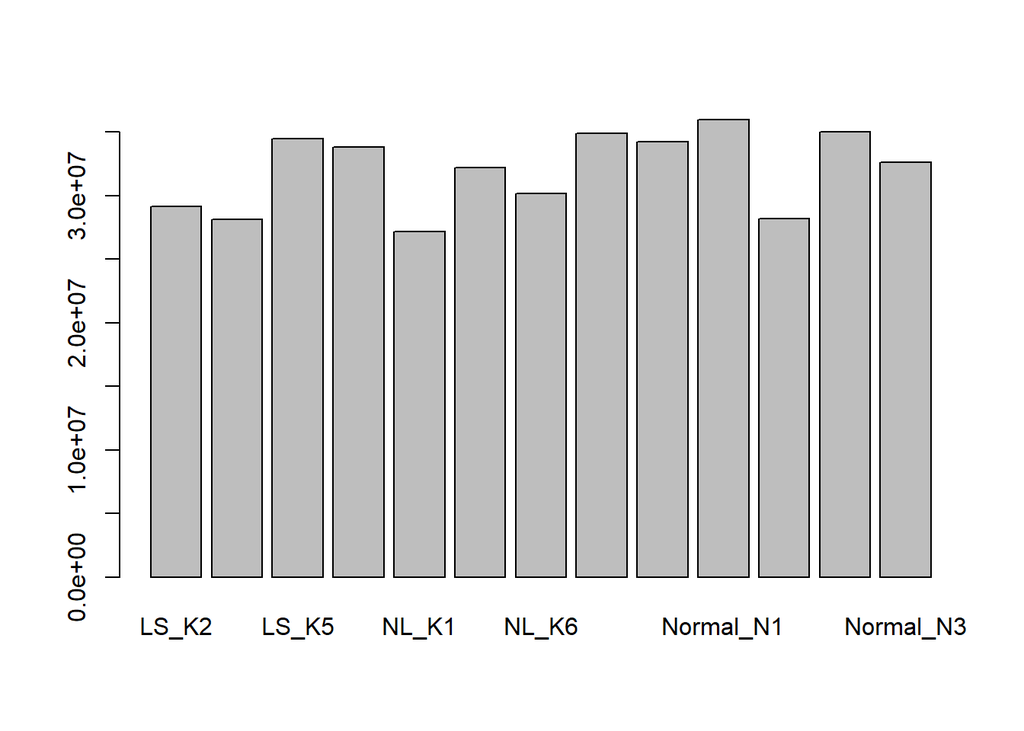

```r
colSums(counts(DESeq.ds)) %>% barplot
```

```r
#remove low reads
dim(DESeq.ds)
```

```
## [1] 62710    13
```

```r
keep_genes <- rowSums(counts(DESeq.ds)) > 10 #filter
DESeq.ds <- DESeq.ds[ keep_genes, ]
dim(DESeq.ds)
```

```
## [1] 27488    13
```

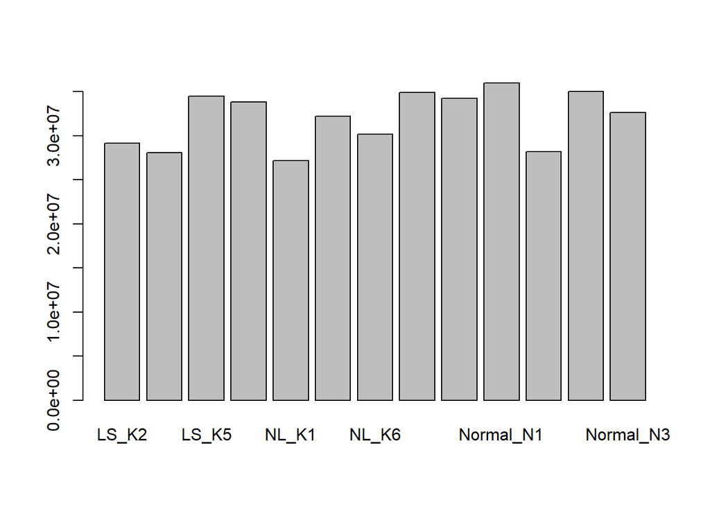

```r
colSums(counts(DESeq.ds)) %>% barplot
```

```r
#set base condition to Normal
DESeq.ds$condition
```

```
##  [1] LS     LS     LS     LS     NL     NL     NL     Normal Normal Normal
## [11] Normal Normal Normal
## Levels: LS NL Normal
```

```r
DESeq.ds$condition %<>% relevel(ref="Normal")
# DESeq.ds$condition <- relevel(DESeq.ds$condition, ref="Normal")
DESeq.ds$condition
```

```
##  [1] LS     LS     LS     LS     NL     NL     NL     Normal Normal Normal
## [11] Normal Normal Normal
## Levels: Normal LS NL
```

Run DE analysis

```r
#Perform DESeq
DESeq.ds %<>% DESeq()
rowData(DESeq.ds) %>% colnames
```

```
##  [1] "baseMean"
##  [2] "baseVar"
##  [3] "allZero"
##  [4] "dispGeneEst"
##  [5] "dispGeneIter"
##  [6] "dispFit"
##  [7] "dispersion"
##  [8] "dispIter"
##  [9] "dispOutlier"
## [10] "dispMAP"
## [11] "Intercept"
## [12] "condition_LS_vs_Normal"
## [13] "condition_NL_vs_Normal"
## [14] "SE_Intercept"
## [15] "SE_condition_LS_vs_Normal"
## [16] "SE_condition_NL_vs_Normal"
## [17] "WaldStatistic_Intercept"
## [18] "WaldStatistic_condition_LS_vs_Normal"
## [19] "WaldStatistic_condition_NL_vs_Normal"
## [20] "WaldPvalue_Intercept"
## [21] "WaldPvalue_condition_LS_vs_Normal"
## [22] "WaldPvalue_condition_NL_vs_Normal"
## [23] "betaConv"
## [24] "betaIter"
## [25] "deviance"
## [26] "maxCooks"
```

```r
library(RColorBrewer)
library(pheatmap)
library(org.Hs.eg.db)
```

### Quality Control

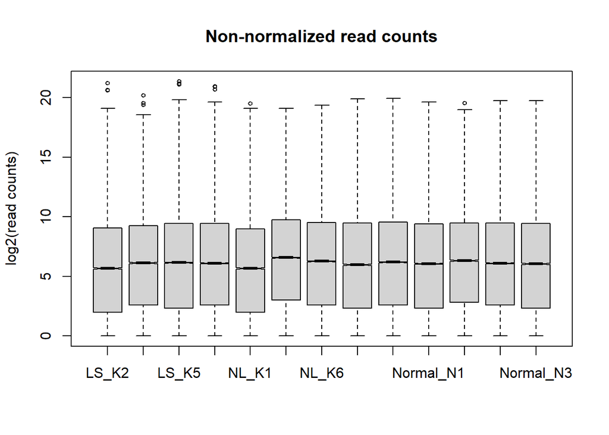

```r
boxplot(log2(counts(DESeq.ds) +1), notch=TRUE,
main = "Non-normalized read counts",
ylab ="log2(read counts)", cex = .6)
```

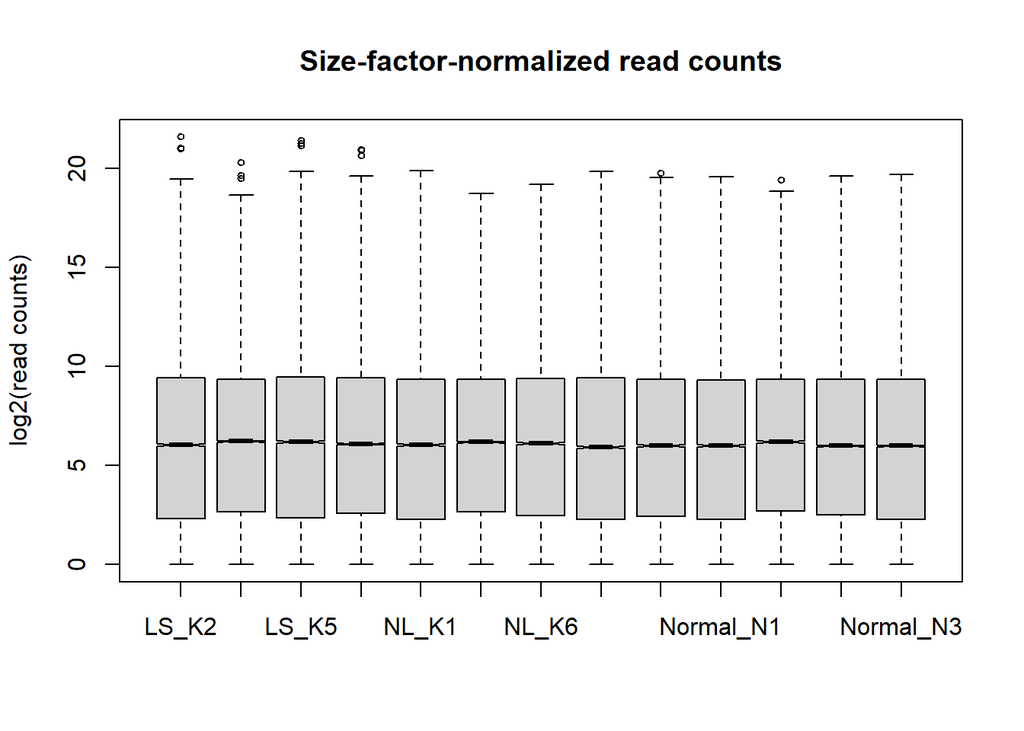

```r
## bp of size-factor normalized values
boxplot(log2(counts(DESeq.ds, normalized=TRUE) +1), notch=TRUE,
main = "Size-factor-normalized read counts",
ylab ="log2(read counts)", cex = .6)
```

```r
png('Plots/dispPlot.png', res=200, width = 1900, height = 1100)
print(plotDispEsts(DESeq.ds))
```

```
## $rect
## $rect$w
## [1] 0.7838108
##
## $rect$h
## [1] 2.119319
##
## $rect$left
## [1] 5.352392
##
## $rect$top
## [1] -6.245239
##
##
## $text
## $text$x
## [1] 5.587239 5.587239 5.587239
##
## $text$y
## [1] -6.775068 -7.304898 -7.834728
```

```r
dev.off()
```

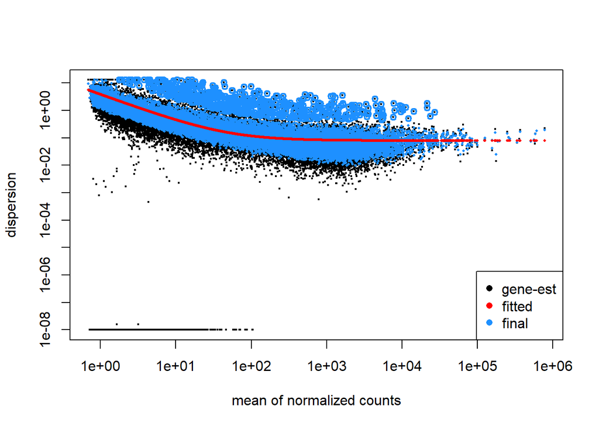

```r
plotDispEsts(DESeq.ds)
```

There are not significant global differences between samples, nonetheless, the normalization helped adjust slight global differences between the samples

Dispersion plot shows that fitted line trends below 1

```r
library(pcaExplorer)
```

[Analyzing RNA-seq data with DESeq2 (bioconductor.org)](https://www.bioconductor.org/packages/release/bioc/vignettes/DESeq2/inst/doc/DESeq2.html#data-quality-assessment-by-sample-clustering-and-visualization)

PCA

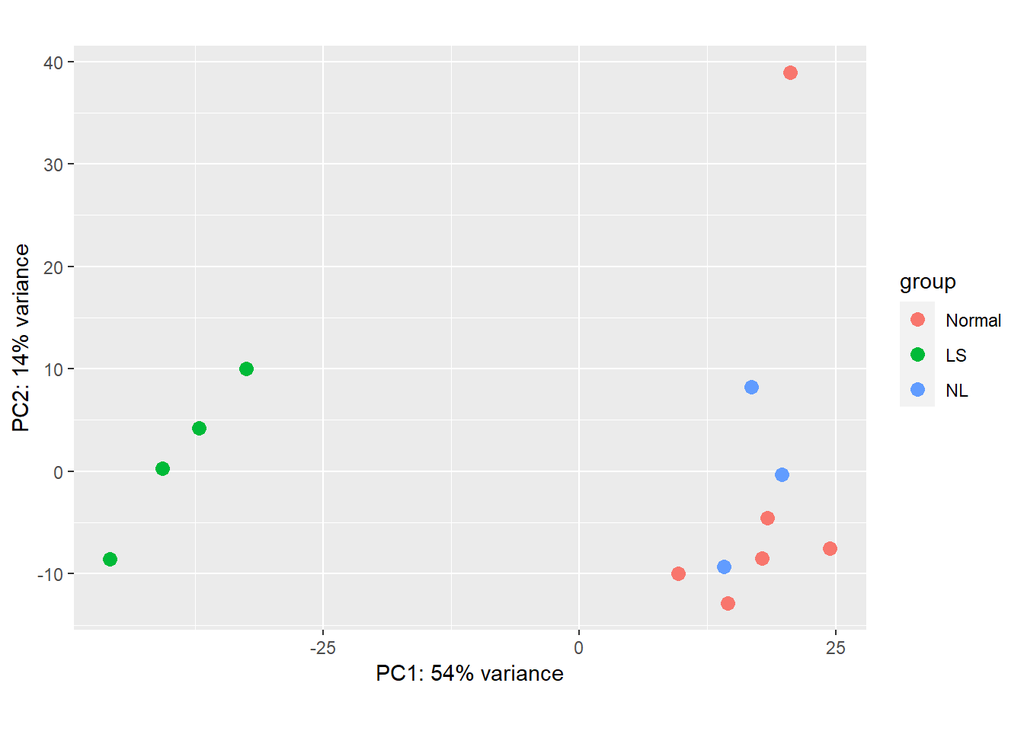

```r
DESeq.rlog <- rlog(DESeq.ds, blind = FALSE)
#pcaExplorer(dds = DESeq.ds, dst = DESeq.rlog)
plotPCA(DESeq.rlog, intgroup=c("condition"))
```

```r
png('Plots/PCA.png', res=250, width = 1900, height = 1100)
print(plotPCA(DESeq.rlog, intgroup=c("condition")))
dev.off()
```

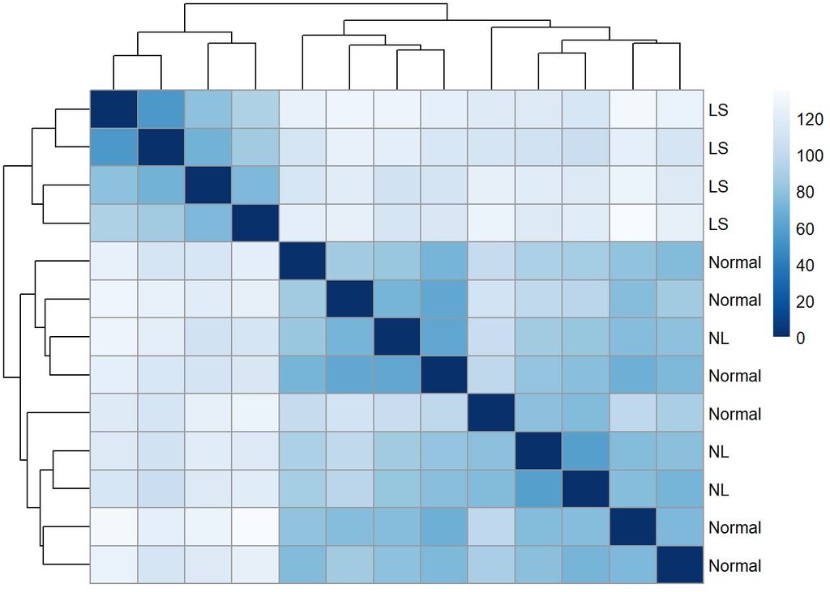

```r
sampleDists <- dist(t(assay(DESeq.rlog)))
sampleDistMatrix <- as.matrix(sampleDists)
rownames(sampleDistMatrix) <- paste(DESeq.rlog$condition)
colnames(sampleDistMatrix) <- NULL
colors <- colorRampPalette( rev(brewer.pal(9, "Blues")) )(255)
sampleDistHeat<-pheatmap(sampleDistMatrix,
         clustering_distance_rows=sampleDists,
         clustering_distance_cols=sampleDists,
         col=colors)
```

```r
png('Plots/sampleDistHeat.png', res=250, width = 1900, height = 1100)
print(sampleDistHeat)
dev.off()
```

These plots somewhat make sense when comparing across the three condition. However, when just looking at the LS group, the results are much more coherent since we would expect to see the biggest difference with the LS group compared to the other two conditions. The LS condition is the group of samples taken from a lesion with keloid, whereas the Normal is healthy non-lesional skin, and NL is also non leasional skin but from patients with keloids on other sites. The latter two groups have the same phenotype so it is not unexpected to see that they do not differ greatly in terms of the transcriptome. When compared with the results from the paper, the Normal and NL group are very similar. The PCA indicates that one of the samples in the control is an outlier (Normal_N20).

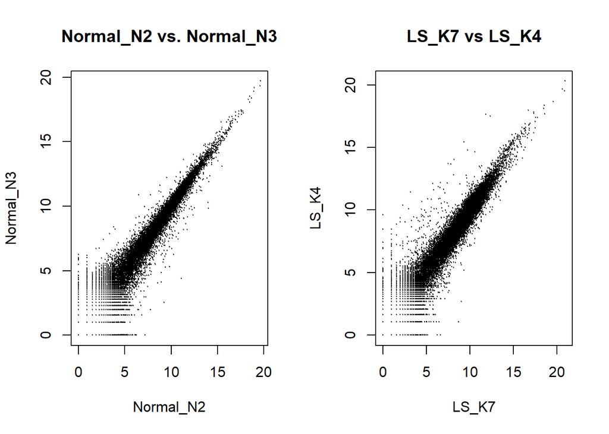

```r
assay(DESeq.ds, "log.counts") <- log2(counts(DESeq.ds, normalized = FALSE) + 1)
## normalized read counts
assay(DESeq.ds, "log.norm.counts") <- log2(counts(DESeq.ds, normalized=TRUE) + 1)
par(mfrow=c(1,2))
DESeq.ds[, c("Normal_N2","Normal_N3")] %>%
assay(., "log.norm.counts") %>%
plot(., cex=.1, main = "Normal_N2 vs. Normal_N3")
DESeq.ds[, c("LS_K7","LS_K4")] %>%
assay(., "log.norm.counts") %>%
plot(., cex=.1, main = "LS_K7 vs LS_K4")
```

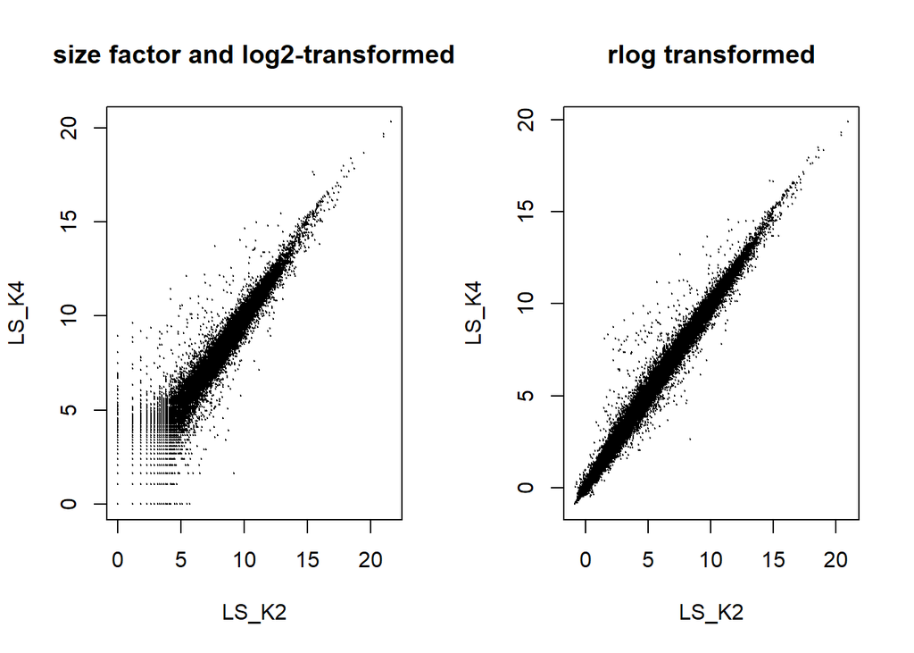

```r
par(mfrow=c(1,2))
plot(assay(DESeq.ds, "log.norm.counts")[,1:2], cex=.1,
main = "size factor and log2-transformed")
## the rlog-transformed counts are stored in the "assay" accessor
plot(assay(DESeq.rlog)[,1:2],
cex=.1, main = "rlog transformed",
xlab = colnames(assay(DESeq.rlog[,1])),
ylab = colnames(assay(DESeq.rlog[,2])) )
```

Variance is tightened when using rlog

### Finding DE genes

Performing DE for each of the three comparisions: Lesional vs healthy control, Non-lesional vs healthy control, Lesional vs Non lesional. Alpha set to 0.05

MA plot

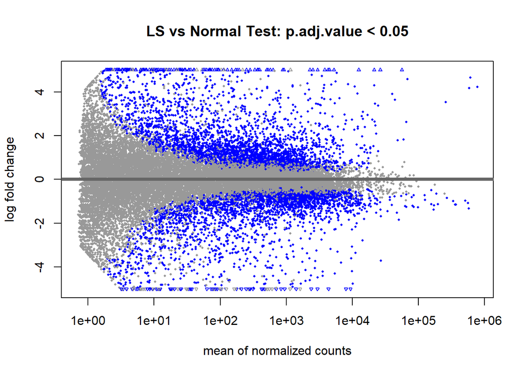

```r
DGE_results_LSvNormal <- results(DESeq.ds, independentFiltering = TRUE, alpha = 0.05, contrast = c("condition","LS", "Normal"))
DGE_results_NLvNormal <- results(DESeq.ds, independentFiltering = TRUE, alpha = 0.05, contrast = c("condition","NL", "Normal"))
DGE_results_LSvNL <- results(DESeq.ds, independentFiltering = TRUE, alpha = 0.05, contrast = c("condition","LS", "NL"))

LSvNormal_MAplot<-plotMA(DGE_results_LSvNormal, alpha=0.05,
main="LS vs Normal Test: p.adj.value < 0.05", ylim = c(-5,5))
```

```r
png('Plots/LSvNormal_MAplot.png', res=250, width = 1900, height = 1100)
print(plotMA(DGE_results_LSvNormal, alpha=0.05,
main="LS vs Normal Test: p.adj.value < 0.05", ylim = c(-5,5)))
```

```r
dev.off()
```

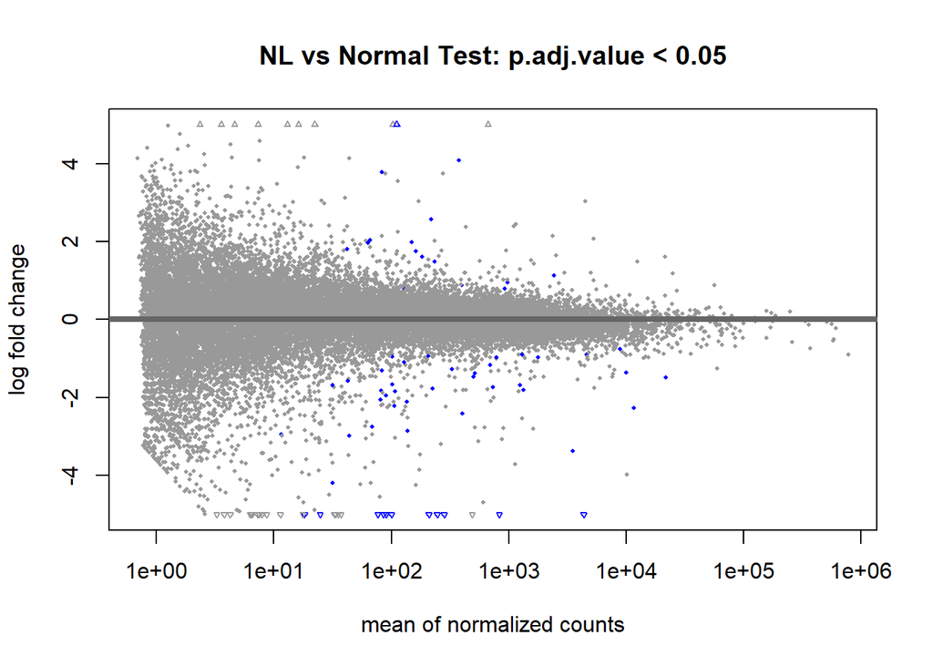

```r
NLvNormal_MAplot<-plotMA(DGE_results_NLvNormal, alpha=0.05,
main="NL vs Normal Test: p.adj.value < 0.05", ylim = c(-5,5))
```

```r
png('Plots/NLvNormal_MAplot.png', res=250, width = 1900, height = 1100)
print(plotMA(DGE_results_NLvNormal, alpha=0.05,
main="NL vs Normal Test: p.adj.value < 0.05", ylim = c(-5,5)))
```

```r
dev.off()
```

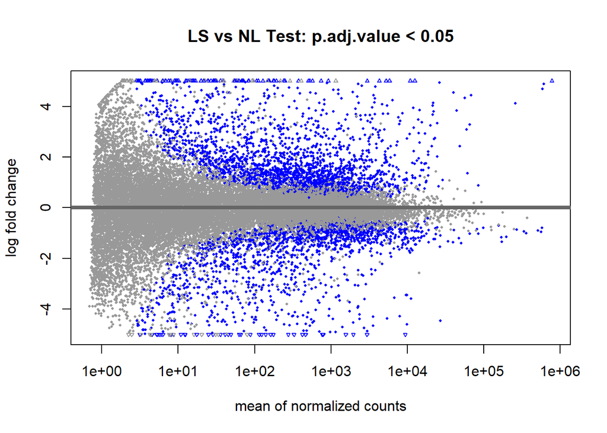

```r
LSvNL_MAplot<-plotMA(DGE_results_LSvNL, alpha=0.05,
main="LS vs NL Test: p.adj.value < 0.05", ylim = c(-5,5))
```

```r
png('Plots/LSvNL_MAplot.png', res=250, width = 1900, height = 1100)
print(plotMA(DGE_results_LSvNL, alpha=0.05,
main="LS vs NL Test: p.adj.value < 0.05", ylim = c(-5,5)))
```

```r
dev.off()
```

```r
LSvNormal_MAplot
```

```r
NLvNormal_MAplot
```

```r
LSvNL_MAplot
```

Much more DE genes in LS vs Normal and LS vs NL. NL vs Normal has very few DE genes in comparison, and is in agreement with the results of PCA.

Removing NA values

```r
dim(DGE_results_NLvNormal)
```

```
## [1] 27488     6
```

```r
DGE_results_NLvNormal<-na.omit(DGE_results_NLvNormal)
dim(DGE_results_NLvNormal)
```

```
## [1] 18830     6
```

```r
dim(DGE_results_LSvNormal)
```

```
## [1] 27488     6
```

```r
DGE_results_LSvNormal<-na.omit(DGE_results_LSvNormal)
dim(DGE_results_LSvNormal)
```

```
## [1] 24637     6
```

```r
dim(DGE_results_LSvNL)
```

```
## [1] 27488     6
```

```r
DGE_results_LSvNL<-na.omit(DGE_results_LSvNL)
dim(DGE_results_LSvNL)
```

```
## [1] 22510     6
```

```r
DGE_results_NLvNormal_sorted <- DGE_results_NLvNormal %>% `[`(order(.$padj),)
DGE_results_LSvNormal_sorted <- DGE_results_LSvNormal %>% `[`(order(.$padj),)
DGE_results_LSvNL_sorted <- DGE_results_LSvNL %>% `[`(order(.$padj),)
```

extract significant gene names (ENSEMBL IDs) by filtering for padj values less than 0.05, and a log2FoldChange greater than 1 or less than -1

```r
NLvNormal_DGEgenes <- rownames(subset(DGE_results_NLvNormal_sorted, padj < 0.05 & abs(log2FoldChange) > 1))
LSvNormal_DGEgenes <- rownames(subset(DGE_results_LSvNormal_sorted, padj < 0.05 & abs(log2FoldChange) > 1))
LSvNL_DGEgenes <- rownames(subset(DGE_results_LSvNL_sorted, padj < 0.05 & abs(log2FoldChange) > 1))
```

### Heatmap of DE genes

Three heatmaps for the three comparisons, displaying the DE genes for each sample.

```r
all_DGEgenes<-unique(c(NLvNormal_DGEgenes, LSvNormal_DGEgenes, LSvNL_DGEgenes))


heatmap_rlog_df<-assay(DESeq.rlog[LSvNormal_DGEgenes,])
ensembl_ids <- rownames(heatmap_rlog_df)
gene_names <- mapIds(org.Hs.eg.db, keys = ensembl_ids, column = "SYMBOL", keytype = "ENSEMBL", multiVals = "first")
rownames(heatmap_rlog_df) <- gene_names
gene_names_LSvNormal <- rownames(heatmap_rlog_df[1:100, ])

LSvNormal_heat<-pheatmap(heatmap_rlog_df[1:50, ], scale="row",show_rownames=TRUE, main="LS vs Normal DGE (row-based z-score)")

png('Plots/LSvNormal_heat.png', res=250, width = 1500, height = 2100)
print(LSvNormal_heat)
dev.off()
```

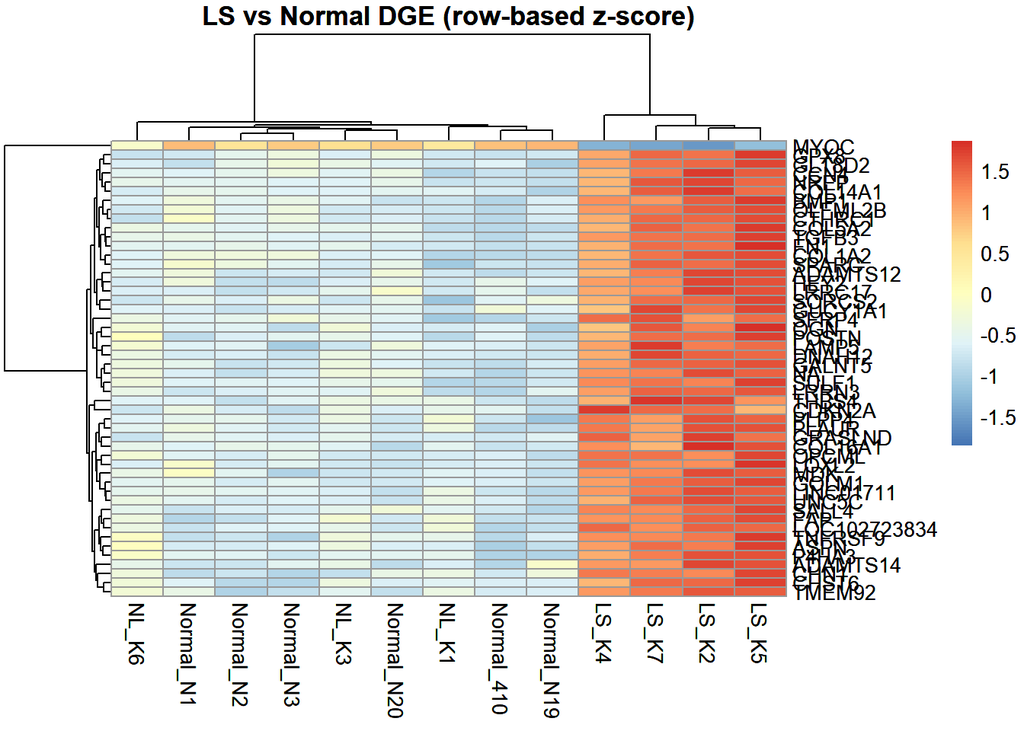

```r
LSvNormal_heat
```

```r
heatmap_rlog_df<-assay(DESeq.rlog[LSvNL_DGEgenes,])
ensembl_ids <- rownames(heatmap_rlog_df)
gene_names <- mapIds(org.Hs.eg.db, keys = ensembl_ids, column = "SYMBOL", keytype = "ENSEMBL", multiVals = "first")
rownames(heatmap_rlog_df) <- gene_names
gene_names_LSvNL <- rownames(heatmap_rlog_df[1:100, ])

LSvNL_heat<-pheatmap(heatmap_rlog_df[1:50, ], scale="row",show_rownames=TRUE, main="LS vs NL DGE (row-based z-score)")
png('Plots/LSvNL_heat.png', res=250, width = 1500, height = 2100)
print(LSvNL_heat)
dev.off()
```

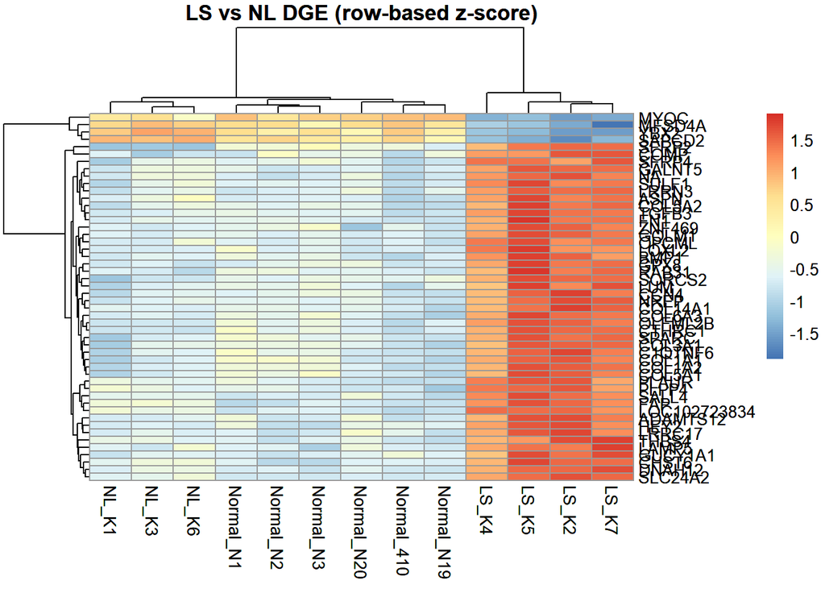

```r
LSvNL_heat
```

```r
heatmap_rlog_df<-assay(DESeq.rlog[NLvNormal_DGEgenes,])
#library(org.Hs.eg.db)
ensembl_ids <- rownames(heatmap_rlog_df)
gene_names <- mapIds(org.Hs.eg.db, keys = ensembl_ids, column = "SYMBOL", keytype = "ENSEMBL", multiVals = "first")
rownames(heatmap_rlog_df) <- gene_names
gene_names_NLvNormal <- rownames(heatmap_rlog_df[1:50, ])

NLvNormal_heat<-pheatmap(heatmap_rlog_df[1:50, ], scale="row",show_rownames=TRUE, main="NL vs Normal DGE (row-based z-score)")
png('Plots/NLvNormal_heat.png', res=250, width = 1500, height = 2100)
print(NLvNormal_heat)
dev.off()
```

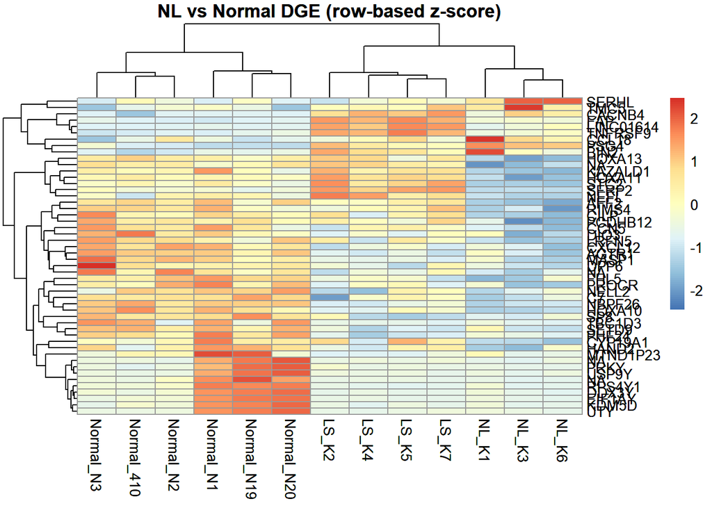

```r
NLvNormal_heat
```

The LS vs Normal and LS vs NL heatmaps show a clear difference in gene expression with the LS samples clustering separately. The LS vs NL heatmaps shows the three conditions separating into three clusters well. In the LS vs Normal heatmap, we can see that the NL and Normal conditions do not separate well. As expected, the NL vs Normal heatmap does not indicate strong expression patterns but surprisingly clustered the samples in three conditions well.

### Volcano Plots

```r
# add column with Gene symbols
DGE_results_NLvNormal_sorted_symbol<-DGE_results_NLvNormal_sorted
DGE_results_LSvNormal_sorted_symbol<-DGE_results_LSvNormal_sorted
DGE_results_LSvNL_sorted_symbol<-DGE_results_LSvNL_sorted

DGE_results_NLvNormal_sorted_symbol$symbol<-mapIds(org.Hs.eg.db, keys = rownames(DGE_results_NLvNormal_sorted_symbol), keytype = "ENSEMBL", column = "SYMBOL")
DGE_results_LSvNormal_sorted_symbol$symbol<-mapIds(org.Hs.eg.db, keys = rownames(DGE_results_LSvNormal_sorted_symbol), keytype = "ENSEMBL", column = "SYMBOL")
DGE_results_LSvNL_sorted_symbol$symbol<-mapIds(org.Hs.eg.db, keys = rownames(DGE_results_LSvNL_sorted_symbol), keytype = "ENSEMBL", column = "SYMBOL")

# plot volcano plots
library(EnhancedVolcano)

NLvNormal_Plot<-EnhancedVolcano(DGE_results_NLvNormal_sorted_symbol,
lab=DGE_results_NLvNormal_sorted_symbol$symbol,
x='log2FoldChange', y='padj', selectLab = gene_names_NLvNormal,
pCutoff=0.05,
title="NL / Normal")
png('Plots/NLvNormal_Plot.png', res=100, width = 1900, height = 1100)
print(NLvNormal_Plot)
dev.off()
```

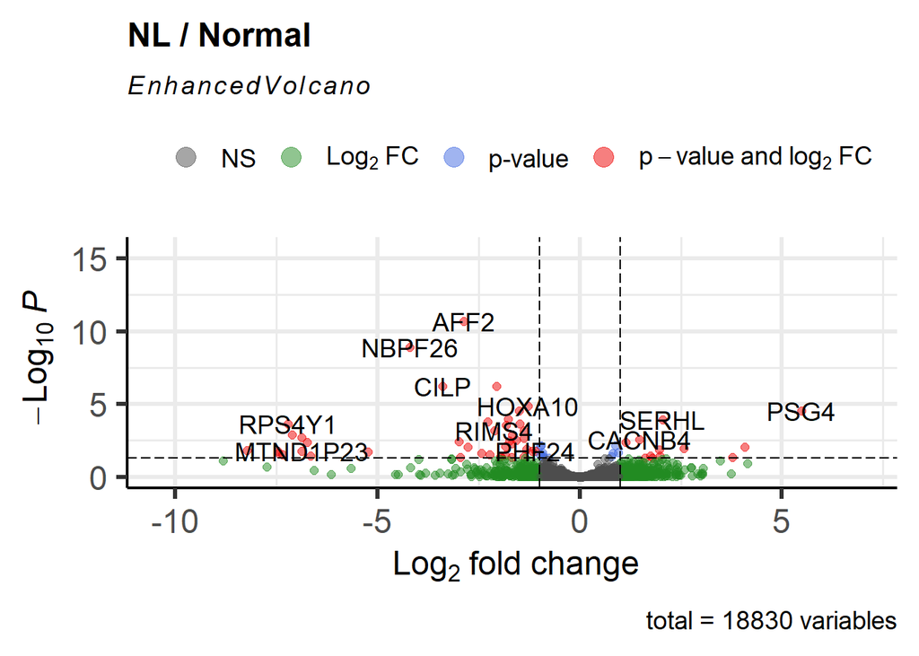

```r
NLvNormal_Plot
```

```r
LSvNormal_Plot<-EnhancedVolcano(DGE_results_LSvNormal_sorted_symbol,
lab=DGE_results_LSvNormal_sorted_symbol$symbol,
x='log2FoldChange', y='padj', selectLab = gene_names_LSvNormal ,
pCutoff=0.05,
title="LS / Normal")
png('Plots/LSvNormal_Plot.png', res=100, width = 1900, height = 1100)
print(LSvNormal_Plot)
dev.off()
```

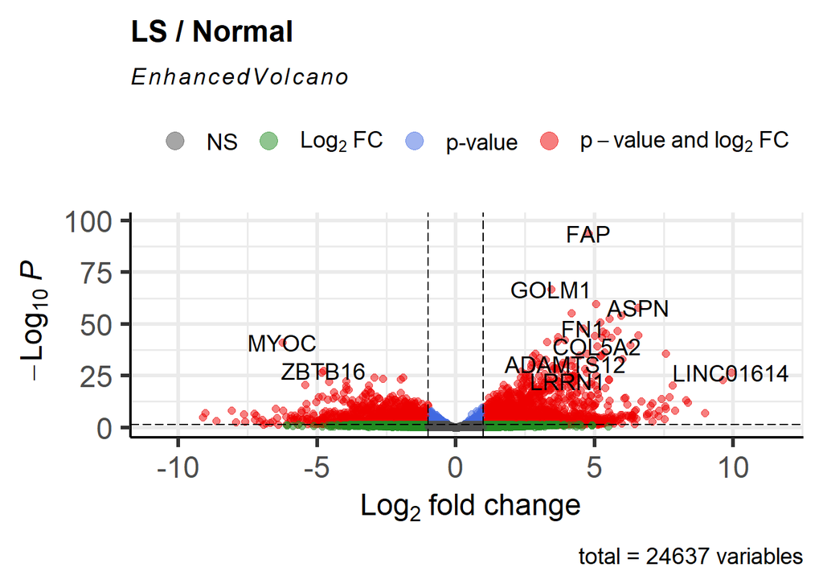

```r
LSvNormal_Plot
```

```r
LSvNL_Plot<-EnhancedVolcano(DGE_results_LSvNL_sorted_symbol,
lab=DGE_results_LSvNL_sorted_symbol$symbol,
x='log2FoldChange', y='padj', selectLab = gene_names_LSvNL ,
pCutoff=0.05,
title="LS / NL")

png('Plots/LSvNL_Plot.png', res=100, width = 1900, height = 1100)
print(LSvNL_Plot)
dev.off()
```

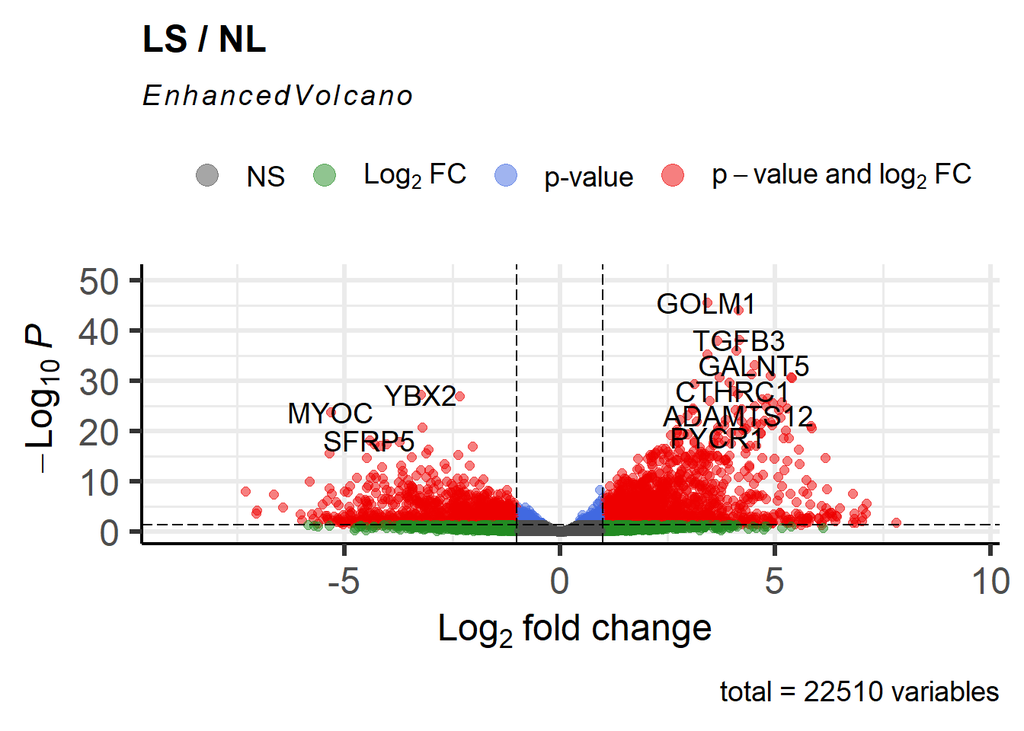

```r
LSvNL_Plot
```

As hypothesized, there is a significant difference in the transcriptomic profile in keloids vs normal skin with many genes being responsible for cell proliferation, inflammation, and bone cartilage.

### Normalized gene expression plots for few genes of interest

```r
df<-plotCounts(DESeq.ds, gene="ENSG00000115414", normalized = TRUE, transform = TRUE, xlab="Condition", returnData = TRUE)
p1<-ggplot(df, aes(x = condition, y = count, fill = condition)) +geom_boxplot()+theme_bw()+labs(x = "Condition", y = "Log2 Normalized Counts", title = "FN1")

df<-plotCounts(DESeq.ds, gene="ENSG00000105664", normalized = TRUE, transform = TRUE, xlab="Condition", returnData = TRUE)
p2<-ggplot(df, aes(x = condition, y = count, fill = condition)) +geom_boxplot()+theme_bw()+labs(x = "Condition", y = "Log2 Normalized Counts", title = "COMP")

df<-plotCounts(DESeq.ds, gene="ENSG00000134013", normalized = TRUE, transform = TRUE, xlab="Condition", returnData = TRUE)
p3<-ggplot(df, aes(x = condition, y = count, fill = condition)) +geom_boxplot()+theme_bw()+labs(x = "Condition", y = "Log2 Normalized Counts", title = "LOXL2")

df<-plotCounts(DESeq.ds, gene="ENSG00000157766", normalized = TRUE, transform = TRUE, xlab="Condition", returnData = TRUE)
p4<-ggplot(df, aes(x = condition, y = count, fill = condition)) +geom_boxplot()+theme_bw()+labs(x = "Condition", y = "Log2 Normalized Counts", title = "ACAN")


df<-plotCounts(DESeq.ds, gene="ENSG00000119699", normalized = TRUE, transform = TRUE, xlab="Condition", returnData = TRUE)
p6<-ggplot(df, aes(x = condition, y = count, fill = condition)) +geom_boxplot()+theme_bw()+labs(x = "Condition", y = "Log2 Normalized Counts", title = "TGFB3")

df<-plotCounts(DESeq.ds, gene="ENSG00000149257", normalized = TRUE, transform = TRUE, xlab="Condition", returnData = TRUE)
p7<-ggplot(df, aes(x = condition, y = count, fill = condition)) +geom_boxplot()+theme_bw()+labs(x = "Condition", y = "Log2 Normalized Counts", title = "SERPINH1")



library(cowplot)

pg<-plot_grid(p1, p2, p3, p4,p6,p7, ncol = 3)


png('Plots/PlotGrid.png', res=250, width = 1900, height = 1100)
print(pg)
dev.off()
```

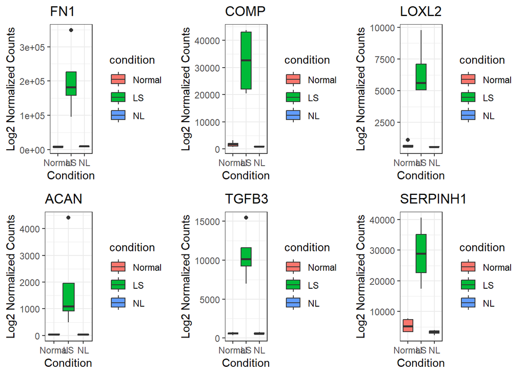

```r
pg
```

## Datasets

```r
rlog_data<-assay(DESeq.rlog)
write.csv(readcounts, "data/counts.csv")
write.csv(rlog_data, "data/rlog_data.csv")
write.csv(DGE_results_NLvNormal_sorted, "data/NLvNormal.csv")
write.csv(DGE_results_LSvNL_sorted, "data/LSvNL.csv")
write.csv(DGE_results_LSvNormal_sorted, "data/LSvNormal.csv")
```

| Data | Link |
| --- | --- |
| Counts data | [angsd_project/counts.csv at main · avk4003/angsd_project (github.com)](https://github.com/avk4003/angsd_project/blob/main/data/counts.csv) |
| rlog data | [angsd_project/rlog_data.csv at main · avk4003/angsd_project (github.com)](https://github.com/avk4003/angsd_project/blob/main/data/rlog_data.csv) |
| DGE_results_NLvNormal_sorted | [angsd_project/NLvNormal.csv at main · avk4003/angsd_project (github.com)](https://github.com/avk4003/angsd_project/blob/main/data/NLvNormal.csv) |
| DGE_results_LSvNL_sorted | [angsd_project/LSvNL.csv at main · avk4003/angsd_project (github.com)](https://github.com/avk4003/angsd_project/blob/main/data/LSvNL.csv) |
| DGE_results_LSvNormal_sorted | [angsd_project/LSvNormal.csv at main · avk4003/angsd_project (github.com)](https://github.com/avk4003/angsd_project/blob/main/data/LSvNormal.csv) |

```r
library(clusterProfiler)
library(AnnotationDbi)
NLvNormal_DGEgenesUP <- rownames(subset(DGE_results_NLvNormal_sorted, padj < 0.05 & log2FoldChange > 1))
LSvNormal_DGEgenesUP <- rownames(subset(DGE_results_LSvNormal_sorted, padj < 0.05 & log2FoldChange > 1))
LSvNL_DGEgenesUP <- rownames(subset(DGE_results_LSvNL_sorted, padj < 0.05 & log2FoldChange > 1))


NLvNormal_DGEgenesDOWN <- rownames(subset(DGE_results_NLvNormal_sorted, padj < 0.05 & log2FoldChange < -1))
LSvNormal_DGEgenesDOWN <- rownames(subset(DGE_results_LSvNormal_sorted, padj < 0.05 & log2FoldChange < -1))
LSvNL_DGEgenesDOWN <- rownames(subset(DGE_results_LSvNL_sorted, padj < 0.05 & log2FoldChange < -1))
```

```r
GO_results_NLvNormal_DGEgenesUP<-enrichGO(gene = NLvNormal_DGEgenesUP, OrgDb = "org.Hs.eg.db", keyType = "ENSEMBL", ont = "BP")
GO_results_LSvNormal_DGEgenesUP<-enrichGO(gene = LSvNormal_DGEgenesUP, OrgDb = "org.Hs.eg.db", keyType = "ENSEMBL", ont = "BP")
GO_results_LSvNL_DGEgenesUP<-enrichGO(gene = LSvNL_DGEgenesUP, OrgDb = "org.Hs.eg.db", keyType = "ENSEMBL", ont = "BP")

GO_results_NLvNormal_DGEgenesDOWN<-enrichGO(gene = NLvNormal_DGEgenesDOWN, OrgDb = "org.Hs.eg.db", keyType = "ENSEMBL", ont = "BP")
GO_results_LSvNormal_DGEgenesDOWN<-enrichGO(gene = LSvNormal_DGEgenesDOWN, OrgDb = "org.Hs.eg.db", keyType = "ENSEMBL", ont = "BP")
GO_results_LSvNL_DGEgenesDOWN<-enrichGO(gene = LSvNL_DGEgenesDOWN, OrgDb = "org.Hs.eg.db", keyType = "ENSEMBL", ont = "BP")
```

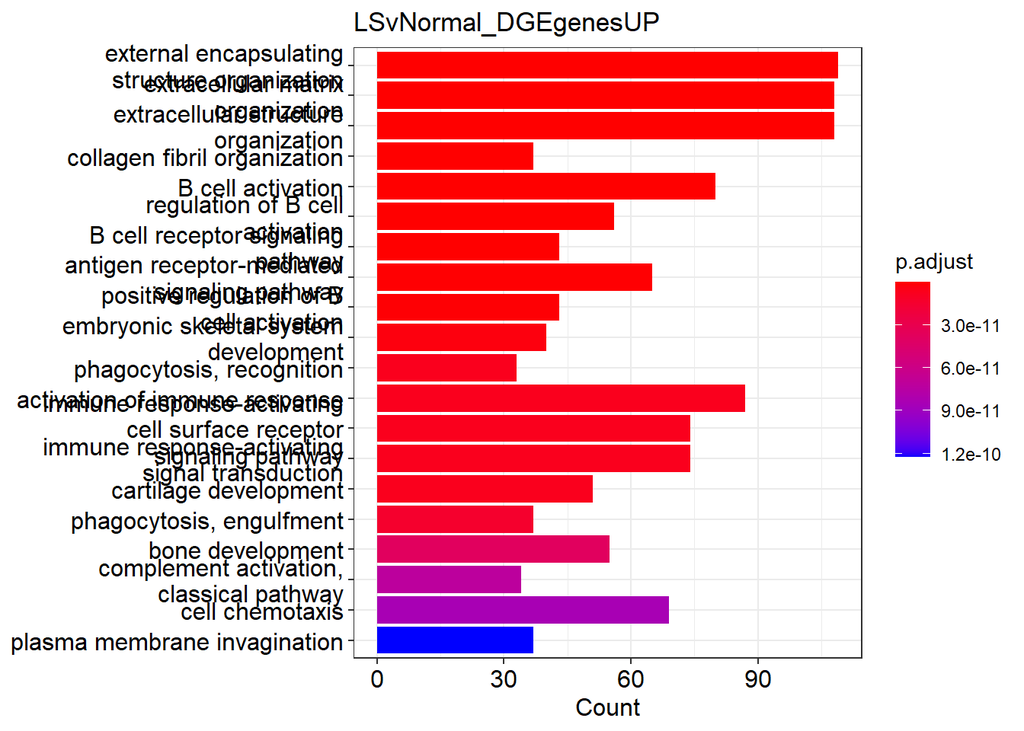

```r
#plot(barplot(GO_results_NLvNormal_DGEgenesUP, showCategory = 20))
UpLSvNormal<-plot(barplot(GO_results_LSvNormal_DGEgenesUP, showCategory = 20, title = "LSvNormal_DGEgenesUP"))
```

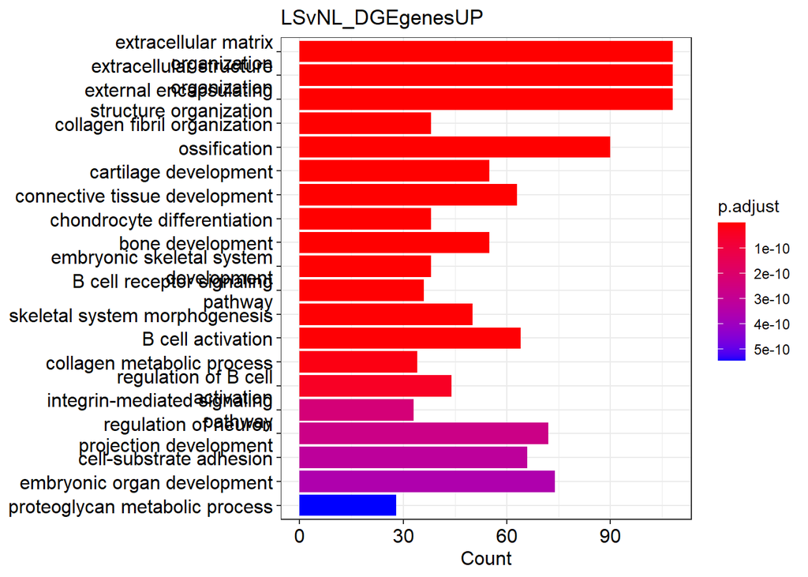

```r
UpLSvNL<-plot(barplot(GO_results_LSvNL_DGEgenesUP, showCategory = 20, title = "LSvNL_DGEgenesUP"))
```

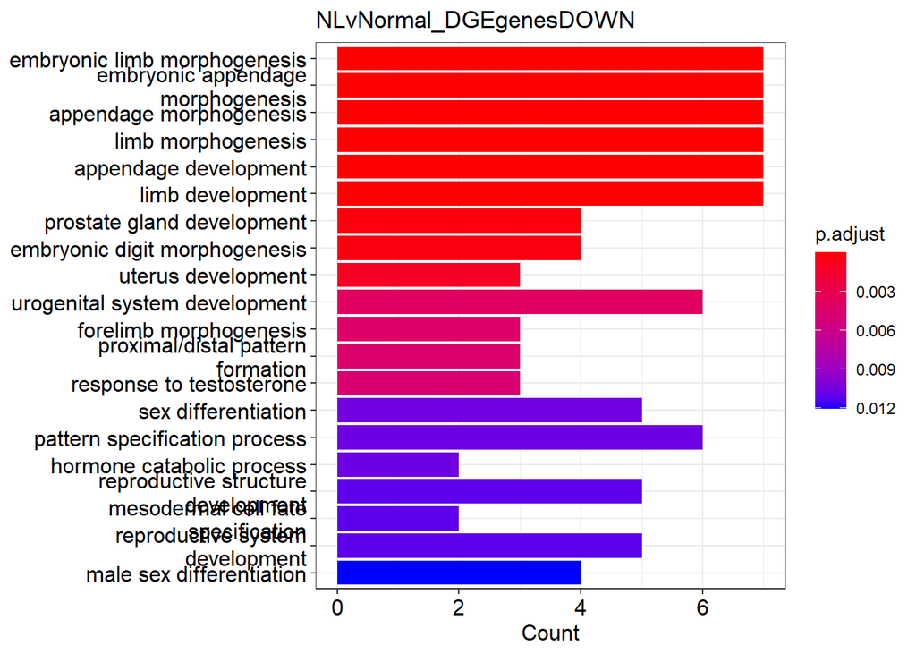

```r
DownNLvNormal<-plot(barplot(GO_results_NLvNormal_DGEgenesDOWN, showCategory = 20, title = "NLvNormal_DGEgenesDOWN"))
```

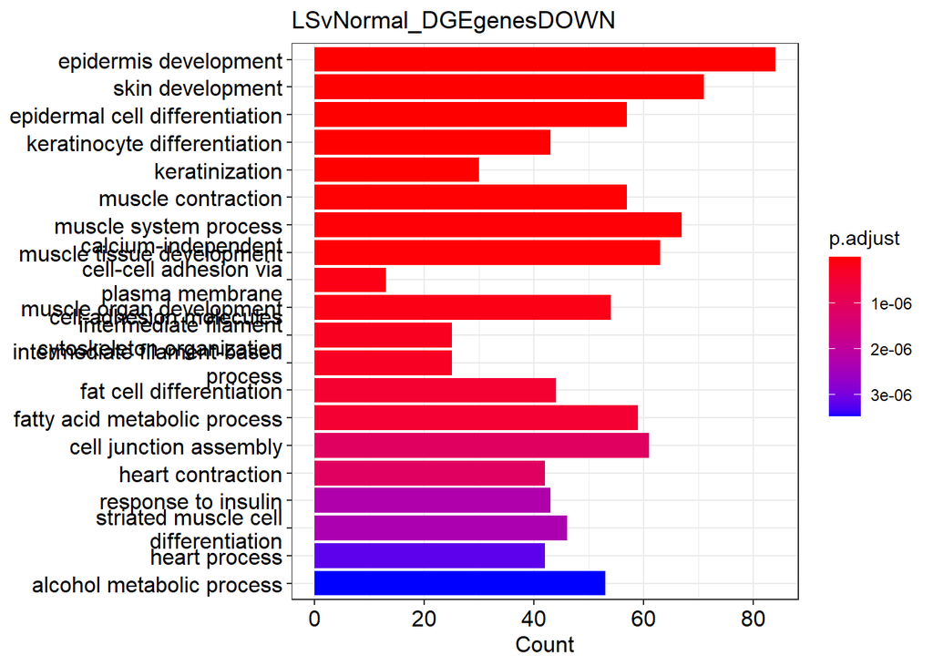

```r
DownLSvNormal<-plot(barplot(GO_results_LSvNormal_DGEgenesDOWN, showCategory = 20, title = "LSvNormal_DGEgenesDOWN"))
```

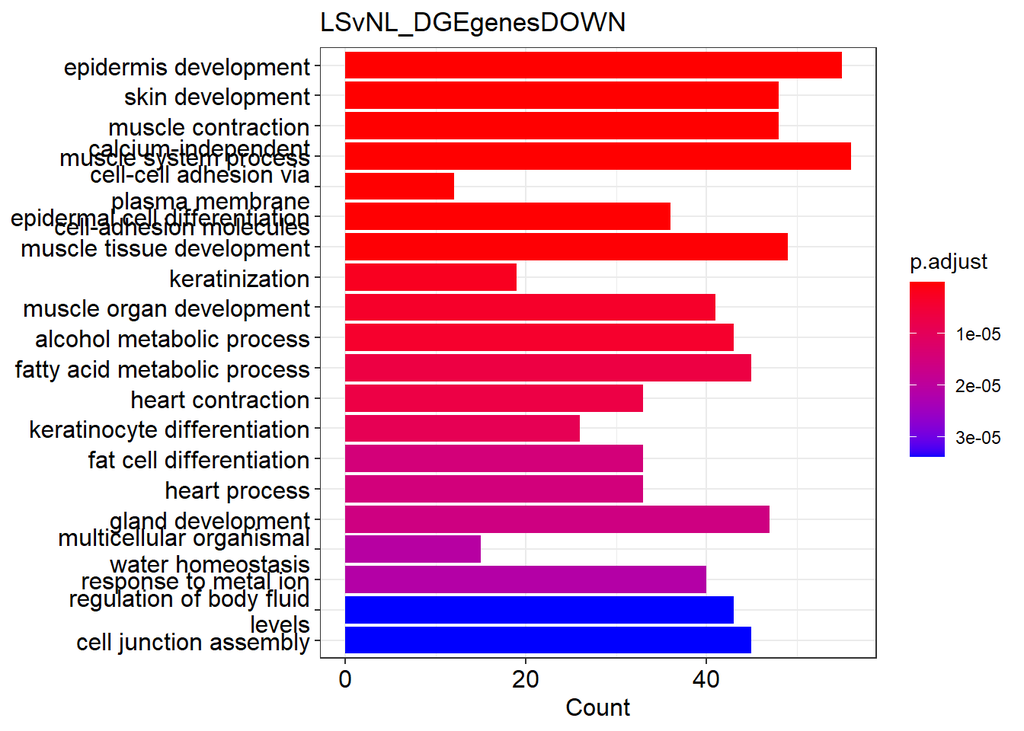

```r
DownLSvNL<-plot(barplot(GO_results_LSvNL_DGEgenesDOWN, showCategory = 20, title = "LSvNL_DGEgenesDOWN"),)
```

```r
png('Plots/UpLSvNL.png', res=110, width = 1900, height = 1100)
print(UpLSvNL)
dev.off()
```

```r
png('Plots/UpLSvNormal.png', res=110, width = 1900, height = 1100)
print(UpLSvNormal)
dev.off()
```

```r
png('Plots/DownNLvNormal.png', res=110, width = 1900, height = 1100)
print(DownNLvNormal)
dev.off()
```

```r
png('Plots/DownLSvNormal.png', res=110, width = 1900, height = 1100)
print(DownLSvNormal)
dev.off()
```

```r
png('Plots/DownLSvNL.png', res=110, width = 1900, height = 1100)
print(DownLSvNL)
dev.off()
```

GO of NL versus Normal upregulated genes revealed 0 pathways. NL versus Normal down-regulated genes do not offer insight into pathways, and the gene counts for the pathways presented are very low. GO of the remaining comparision yield useful insight. GO shows upregulation of immune system, collagen fibril organisation, ossification, extracelular matrix organisation, and down regulation of epidermis and skin development, and epidermal differentiation in the keloid condition.